# CourseraMachineLearningProject

AD

December 1, 2018

## Background

Using devices such as Jawbone Up, Nike FuelBand, and Fitbit it is now possible to collect a large amount of data about personal activity relatively inexpensively. These type of devices are part of the quantified self movement - a group of enthusiasts who take measurements about themselves regularly to improve their health, to find patterns in their behavior, or because they are tech geeks. One thing that people regularly do is quantify how much of a particular activity they do, but they rarely quantify how well they do it. In this project, your goal will be to use data from accelerometers on the belt, forearm, arm, and dumbell of 6 participants. They were asked to perform barbell lifts correctly and incorrectly in 5 different ways. More information is available from the website here: http://groupware.les.inf.puc-rio.br/har (see the section on the Weight Lifting Exercise Dataset).

## Data

The training data for this project are available here:

https://d396qusza40orc.cloudfront.net/predmachlearn/pml-training.csv

The test data are available here:

https://d396qusza40orc.cloudfront.net/predmachlearn/pml-testing.csv

The data for this project come from this source: http://groupware.les.inf.puc-rio.br/har. If you use the document you create for this class for any purpose please cite them as they have been very generous in allowing their data to be used for this kind of assignment.

## Goal

The goal of your project is to predict the manner in which they did the exercise. This is the “classe” variable in the training set. You may use any of the other variables to predict with. You should create a report describing how you built your model, how you used cross validation, what you think the expected out of sample error is, and why you made the choices you did. You will also use your prediction model to predict 20 different test cases.

## Basic Exploratory Data Analysis

### Load Packages

```r
library(caret)
library(rpart)
```

```r
library(rpart.plot)
library(rattle)
library(randomForest)
library(doParallel)
```

### Getting and Clean the data

```r
traindata <- read.csv("https://d396qusza40orc.cloudfront.net/predmachlearn/pml-training.csv", na.strings = c("NA","#DIV/0!",""))

testdata <- read.csv("https://d396qusza40orc.cloudfront.net/predmachlearn/pml-testing.csv", na.strings = c("NA","#DIV/0!",""))


dim(traindata)
```

```
## [1] 19622   160
```

```r
dim(testdata)
```

```
## [1]  20 160
```

```r
traindata <- traindata[,colSums(is.na(traindata)) == 0]
dim(traindata)
```

```
## [1] 19622    60
```

```r
summary(traindata)
```

```
##        X            user_name    raw_timestamp_part_1 raw_timestamp_part_2
##  Min.   :    1   adelmo  :3892   Min.   :1.322e+09    Min.   :   294
##  1st Qu.: 4906   carlitos:3112   1st Qu.:1.323e+09    1st Qu.:252912
##  Median : 9812   charles :3536   Median :1.323e+09    Median :496380
##  Mean   : 9812   eurico  :3070   Mean   :1.323e+09    Mean   :500656
##  3rd Qu.:14717   jeremy  :3402   3rd Qu.:1.323e+09    3rd Qu.:751891
##  Max.   :19622   pedro   :2610   Max.   :1.323e+09    Max.   :998801
##
##           cvtd_timestamp  new_window    num_window      roll_belt
##  28/11/2011 14:14: 1498   no :19216   Min.   :  1.0   Min.   :-28.90
##  05/12/2011 11:24: 1497   yes:  406   1st Qu.:222.0   1st Qu.:  1.10
##  30/11/2011 17:11: 1440               Median :424.0   Median :113.00
##  05/12/2011 11:25: 1425               Mean   :430.6   Mean   : 64.41
##  02/12/2011 14:57: 1380               3rd Qu.:644.0   3rd Qu.:123.00
##  02/12/2011 13:34: 1375               Max.   :864.0   Max.   :162.00
##  (Other)         :11007
##    pitch_belt          yaw_belt       total_accel_belt  gyros_belt_x
##  Min.   :-55.8000   Min.   :-180.00   Min.   : 0.00    Min.   :-1.040000
##  1st Qu.:  1.7600   1st Qu.: -88.30   1st Qu.: 3.00    1st Qu.:-0.030000
##  Median :  5.2800   Median : -13.00   Median :17.00    Median : 0.030000
##  Mean   :  0.3053   Mean   : -11.21   Mean   :11.31    Mean   :-0.005592
##  3rd Qu.: 14.9000   3rd Qu.:  12.90   3rd Qu.:18.00    3rd Qu.: 0.110000
##  Max.   : 60.3000   Max.   : 179.00   Max.   :29.00    Max.   : 2.220000
##
##   gyros_belt_y       gyros_belt_z      accel_belt_x       accel_belt_y
##  Min.   :-0.64000   Min.   :-1.4600   Min.   :-120.000   Min.   :-69.00
##  1st Qu.: 0.00000   1st Qu.:-0.2000   1st Qu.: -21.000   1st Qu.:  3.00
##  Median : 0.02000   Median :-0.1000   Median : -15.000   Median : 35.00
##  Mean   : 0.03959   Mean   :-0.1305   Mean   :  -5.595   Mean   : 30.15
##  3rd Qu.: 0.11000   3rd Qu.:-0.0200   3rd Qu.:  -5.000   3rd Qu.: 61.00
##  Max.   : 0.64000   Max.   : 1.6200   Max.   :  85.000   Max.   :164.00
##
##   accel_belt_z     magnet_belt_x   magnet_belt_y   magnet_belt_z
##  Min.   :-275.00   Min.   :-52.0   Min.   :354.0   Min.   :-623.0
##  1st Qu.:-162.00   1st Qu.:  9.0   1st Qu.:581.0   1st Qu.:-375.0
##  Median :-152.00   Median : 35.0   Median :601.0   Median :-320.0
##  Mean   : -72.59   Mean   : 55.6   Mean   :593.7   Mean   :-345.5
##  3rd Qu.:  27.00   3rd Qu.: 59.0   3rd Qu.:610.0   3rd Qu.:-306.0
##  Max.   : 105.00   Max.   :485.0   Max.   :673.0   Max.   : 293.0
##
```

[output cut: 73 more lines]

```
##  Min.   :-446.00   Min.   :-1280.0   Min.   :-896.0   Min.   :-973.0
##  1st Qu.:-182.00   1st Qu.: -616.0   1st Qu.:   2.0   1st Qu.: 191.0
##  Median : -39.00   Median : -378.0   Median : 591.0   Median : 511.0
##  Mean   : -55.29   Mean   : -312.6   Mean   : 380.1   Mean   : 393.6
##  3rd Qu.:  26.00   3rd Qu.:  -73.0   3rd Qu.: 737.0   3rd Qu.: 653.0
##  Max.   : 291.00   Max.   :  672.0   Max.   :1480.0   Max.   :1090.0
##
##  classe
##  A:5580
##  B:3797
##  C:3422
##  D:3216
##  E:3607
##
##
```

```r
testdata <- testdata[,colSums(is.na(testdata)) == 0]
dim(testdata)
```

```
## [1] 20 60
```

Exclude the columns that are not part of the prediction process

```r
traindata <- traindata[,-c(1:7)]
testdata <- testdata[,-c(1:7)]
dim(traindata)
```

```
## [1] 19622    53
```

## Data Slicing

Split the training data set into 70% of training data set and 30% testing data set

```r
itrain <- createDataPartition(traindata$classe, p =0.7, list = FALSE)
itraindata <- traindata[itrain,]
itest <- traindata[-itrain,]
dim(itraindata)
```

```
## [1] 13737    53
```

```r
dim(itest)
```

```
## [1] 5885   53
```

## k-fold Cross Validation

Split the data into 5 subsets

```r
registerDoParallel(cores=5)
tcontrol <- trainControl(method = "cv", number = 5)
```

## Classification Tree Model

Build the Classification Tree Model. Predict and note the Accuracy and out of sample error for the Classification Tree Model.

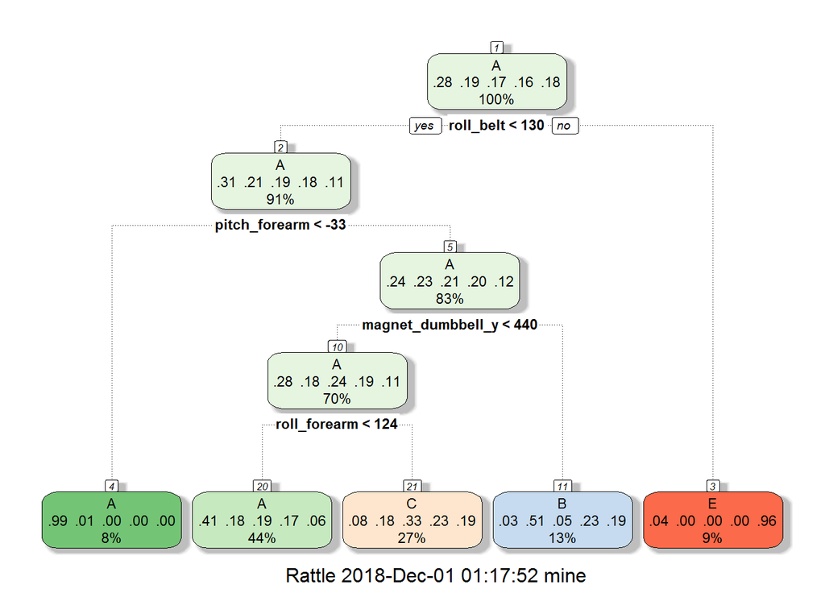

```r
ctreemod <- train(classe ~ .,data = itraindata, method = "rpart", trControl=tcontrol)
fancyRpartPlot(ctreemod$finalModel)
```

```r
predict_ctree <- predict(ctreemod, itest, type = "raw")
confusionMatrix(predict_ctree,itest$classe)
```

```
## Confusion Matrix and Statistics
##
##           Reference
## Prediction    A    B    C    D    E
##          A 1499  490  478  440  149
##          B   30  382   28  163  134
##          C  119  267  520  361  272
##          D    0    0    0    0    0
##          E   26    0    0    0  527
##
## Overall Statistics
##
##                Accuracy : 0.4975
##                  95% CI : (0.4847, 0.5104)
##     No Information Rate : 0.2845
##     P-Value [Acc > NIR] : < 2.2e-16
##
##                   Kappa : 0.3433
##  Mcnemar's Test P-Value : NA
##
## Statistics by Class:
##
##                      Class: A Class: B Class: C Class: D Class: E
## Sensitivity            0.8955  0.33538  0.50682   0.0000  0.48706
## Specificity            0.6303  0.92520  0.79029   1.0000  0.99459
## Pos Pred Value         0.4905  0.51832  0.33788      NaN  0.95298
## Neg Pred Value         0.9381  0.85295  0.88357   0.8362  0.89591
## Prevalence             0.2845  0.19354  0.17434   0.1638  0.18386
## Detection Rate         0.2547  0.06491  0.08836   0.0000  0.08955
## Detection Prevalence   0.5193  0.12523  0.26151   0.0000  0.09397
## Balanced Accuracy      0.7629  0.63029  0.64855   0.5000  0.74082
```

Out of Sample Error

```r
dterror <- 1 - as.numeric(confusionMatrix(predict_ctree,itest$classe)$overall[1])
dterror
```

```
## [1] 0.5024639
```

Accuracy

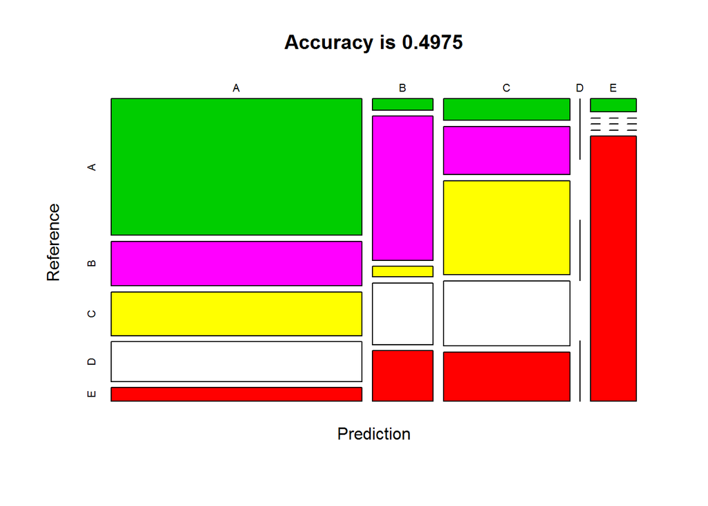

```r
ctreecmat <- confusionMatrix(predict_ctree,itest$classe)
plot(ctreecmat$table,col = ctreecmat$byClass, color = ctreecmat$table,main = paste("Accuracy is",round(ctreecmat$overall['Accuracy'],4)))
```

## Random Forest Model

Build the Random Forest Model. Predict and note the Accuracy and out of sample error for the Random Forest Model.

```r
rforestmod <- train(classe ~ .,data = itraindata,method =  "rf",trControl=tcontrol)

predict_rforest <- predict(rforestmod, itest, type = "raw")
confusionMatrix(predict_rforest,itest$classe)
```

```
## Confusion Matrix and Statistics
##
##           Reference
## Prediction    A    B    C    D    E
##          A 1673    8    0    0    0
##          B    1 1129   11    0    0
##          C    0    1 1012    6    3
##          D    0    1    3  956    1
##          E    0    0    0    2 1078
##
## Overall Statistics
##
##                Accuracy : 0.9937
##                  95% CI : (0.9913, 0.9956)
##     No Information Rate : 0.2845
##     P-Value [Acc > NIR] : < 2.2e-16
##
##                   Kappa : 0.992
##  Mcnemar's Test P-Value : NA
##
## Statistics by Class:
##
##                      Class: A Class: B Class: C Class: D Class: E
## Sensitivity            0.9994   0.9912   0.9864   0.9917   0.9963
## Specificity            0.9981   0.9975   0.9979   0.9990   0.9996
## Pos Pred Value         0.9952   0.9895   0.9902   0.9948   0.9981
## Neg Pred Value         0.9998   0.9979   0.9971   0.9984   0.9992
## Prevalence             0.2845   0.1935   0.1743   0.1638   0.1839
## Detection Rate         0.2843   0.1918   0.1720   0.1624   0.1832
## Detection Prevalence   0.2856   0.1939   0.1737   0.1633   0.1835
## Balanced Accuracy      0.9988   0.9943   0.9921   0.9953   0.9979
```

Out of Sample Error

```r
rferror <- 1 - as.numeric(confusionMatrix(predict_rforest,itest$classe)$overall[1])
rferror
```

```
## [1] 0.006287171
```

Accuracy

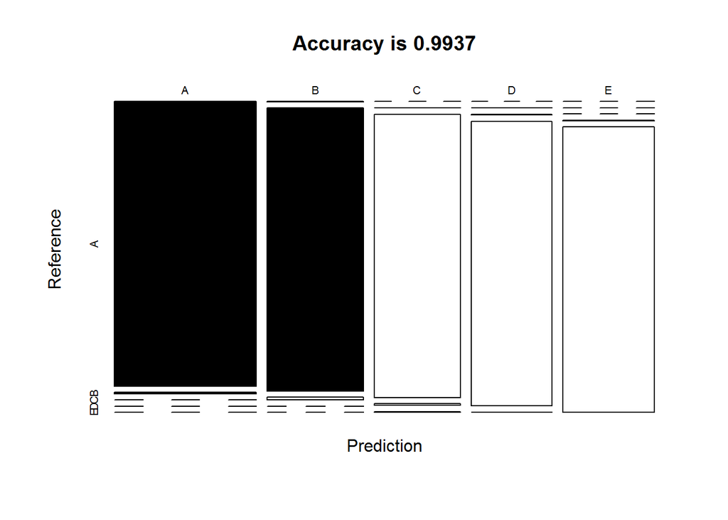

```r
rforestcmat <- confusionMatrix(predict_rforest,itest$classe)

plot(rforestcmat$table,col = rforestcmat$byClass, color = rforestcmat$table, main = paste("Accuracy is",round(rforestcmat$overall['Accuracy'],4)))
```

## Predict Based on the Testing Data

Accuracy for Random Forest model is 99%, hence this model will be used to predict the test data set i.e. 20 test cases.

```r
predict_rfdata <- predict(rforestmod,testdata)
predict_rfdata
```

```
##  [1] B A B A A E D B A A B C B A E E A B B B
## Levels: A B C D E
```

## Conclusion

The training data was divided into two sets, training and validation sets. K-fold Cross Validation with Random Forest Model provides 99% accuracy and 0.6% out of sample error rate. K-fold Cross Validation with Classification Tree Model provides 49% accuracy and 50% out of sample error rate. Finally, Random Forest model is used to predict the Testing data set provided in pml-testing.csv i.e. 20 test cases.